# Dublin Marathon 2018

Alok Kumar Singh

## Introduction

The Dublin Marathon data consisted of 22 variables on 16433 observations. I decided to remove the variables YouTube, YourRaceVideo and Share as they contained a lot of Na’s and I decided not to use them in our analysis. In part 1 I looked at the top 100 places amongst the categories of groups running then looked at the Guntime amongst the different groups. I divided up the categories by gender and looked at the proportion of males and females in each category. In part 2 I looked at the average speed for the first half and last half of the marathon amongst the different running groups. Finally, in part 3 I looked at the proportion of each gender in a club or not and then whether the participants were in a club or not by category. I ran a linear model to see whether being in a club and your age affected on your finishing time.

## The Analysis

PART 1

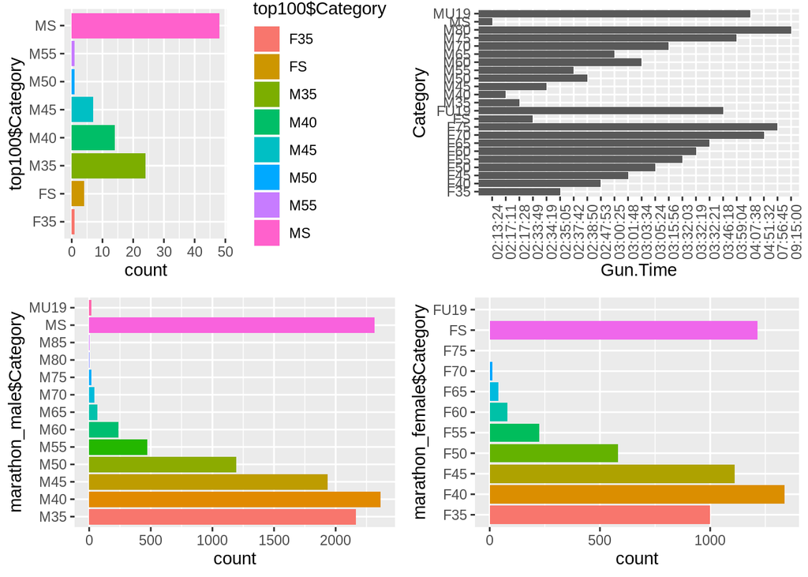

```r
suppressMessages(library(ggplot2))
suppressMessages(library(dplyr))


suppressMessages(marathon<-read.csv("/rstudio_files/ST661/dublin2018marathon.csv",stringsAsFactors = F))
suppressMessages(library(alr4))

top100<-marathon[1:100,]
top_1<-
  marathon %>% group_by(Category) %>%
  filter(Category.Position==1)

##Male data as per categories
marathon_male<-subset(marathon,marathon$Gender=="Male")
marathon_male_cat<-table(as.factor(as.vector(marathon_male$Category)))
##Female data as per categories
marathon_female<-subset(marathon,marathon$Gender=="Female")
marathon_female_cat<-table(as.factor(as.vector(marathon_female$Category)))

t1<-ggplot(data=top100) +
geom_bar(mapping = aes(x=top100$Category,fill=top100$Category))+
coord_flip()

t2<-ggplot(data=top_1) +
  geom_bar(mapping =aes(x=Category,y=Gun.Time),stat="identity")+
  theme(axis.text.x = element_text(angle = 90), legend.position="none") +
  xlab("Category") +
  coord_flip()

plot1<-ggplot(data=marathon_male) +
geom_bar(mapping =
aes(x=marathon_male$Category,fill=marathon_male$Category))+theme(legend.position = "none")+
coord_flip()


plot2<-ggplot(data=marathon_female) +
geom_bar(mapping =
aes(x=marathon_female$Category,fill=marathon_female$Category
))+theme(legend.position = "none")+coord_flip()


suppressMessages(require(gridExtra))
grid.arrange(t1, t2,plot1, plot2,ncol=2,nrow=2)
```

```r
#nrow(filter(top100,top100$Gender=="Male")) ##males in top 100

#nrow(filter(top100,top100$Gender=="Female")) ##females in top 100

#sum(marathon_male_cat) ## males competed

#sum(marathon_female_cat) ## females competed
marathon_male_cat
```

```
##
##  M35  M40  M45  M50  M55  M60  M65  M70  M75  M80  M85   MS MU19
## 2164 2365 1935 1194  470  239   65   40   19    2    1 2315   17
```

```r
marathon_female_cat
```

```
##
##  F35  F40  F45  F50  F55  F60  F65  F70  F75   FS FU19
##  998 1337 1112  583  225   81   40   13    1 1215    2
```

There were 5607 females and 10826 males competing. In the first graph, I saw that the top 100 finishers consisted mostly of category MS(Male Singles). In the second graph, I saw that there was a big difference amongst all categories of runners and their gun time. In the bottom two graphs, I saw that we have a higher proportion of singles and 40’s for both genders.

PART2

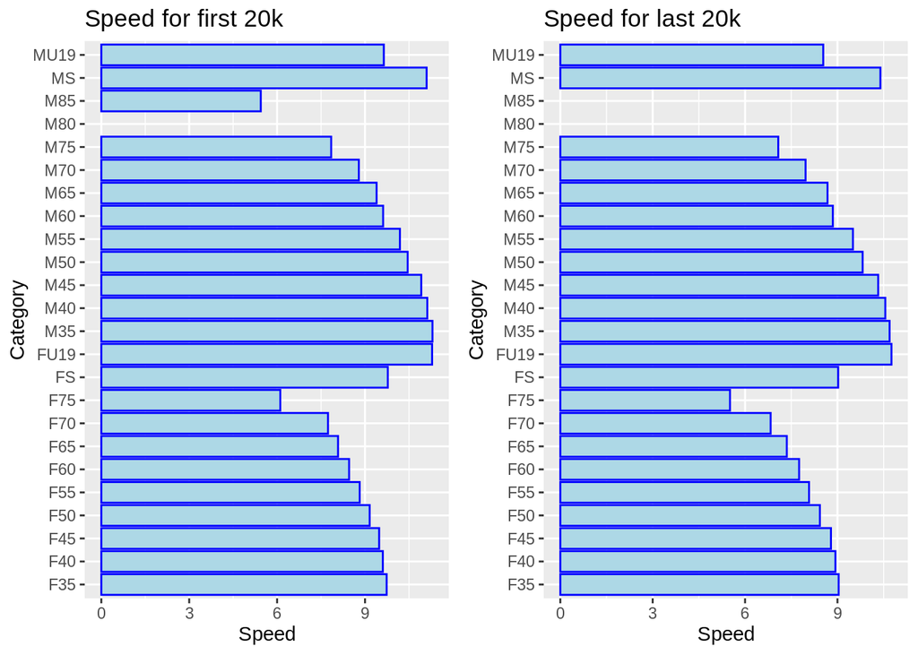

```r
library(tidyr)
dublin2018marathon <-marathon

# Cleaning data set by removing unwanted columns i.e YouTube ,Your.Race.Video , Share by pointing it to NULL
dublin2018marathon_new <- dublin2018marathon
dublin2018marathon_new$YouTube <-
dublin2018marathon_new$Your.Race.Video<-dublin2018marathon_new$Share<- NULL

 ##To create a new data set with times
dublin2018marathon_time <- select(dublin2018marathon_new,Category =
Category , Speed1 = X10K, Speed2 = Halfway, Speed3 = X30K, Speed4 =
Gun.Time)

# To seperate the time fields into hour, minutes and seconds
dublin2018marathon_time <- dublin2018marathon_time %>% separate(Speed1, into = c("hour1","minutes1","seconds1"),extra =
"drop",fill = "right") %>% separate(Speed2, into =
c("hour2","minutes2","seconds2"),extra = "drop",fill = "right") %>%
separate(Speed3, into = c("hour3","minutes3","seconds3"),extra =
"drop",fill = "right") %>% separate(Speed4, into =
c("hour4","minutes4","seconds4"),extra = "drop",fill = "right")
##dublin2018marathon_time
# To convert the character field into the numeric
suppressWarnings({
dublin2018marathon_time$hour1 <-
as.numeric(as.character(dublin2018marathon_time$hour1))
dublin2018marathon_time$minutes1 <-
as.numeric(as.character(dublin2018marathon_time$minutes1))
dublin2018marathon_time$seconds1 <-
as.numeric(as.character(dublin2018marathon_time$seconds1))
dublin2018marathon_time$hour2 <-
as.numeric(as.character(dublin2018marathon_time$hour2))
dublin2018marathon_time$minutes2 <-
as.numeric(as.character(dublin2018marathon_time$minutes2))
dublin2018marathon_time$seconds2 <-
as.numeric(as.character(dublin2018marathon_time$seconds2))
dublin2018marathon_time$hour3 <-
as.numeric(as.character(dublin2018marathon_time$hour3))
dublin2018marathon_time$minutes3 <-
as.numeric(as.character(dublin2018marathon_time$minutes3))
dublin2018marathon_time$seconds3 <-
as.numeric(as.character(dublin2018marathon_time$seconds3))
dublin2018marathon_time$hour4 <-
as.numeric(as.character(dublin2018marathon_time$hour4))
dublin2018marathon_time$minutes4 <-
as.numeric(as.character(dublin2018marathon_time$minutes4))
dublin2018marathon_time$seconds4 <-
as.numeric(as.character(dublin2018marathon_time$seconds4))
})
# To convert minutes and seconds into hour
dublin2018marathon_time$minutes1 <- dublin2018marathon_time$minutes1 /
60
dublin2018marathon_time$minutes2 <- dublin2018marathon_time$minutes2 /
60
dublin2018marathon_time$minutes3 <- dublin2018marathon_time$minutes3 /
60
dublin2018marathon_time$minutes4 <- dublin2018marathon_time$minutes4 /
60
dublin2018marathon_time$seconds1 <- dublin2018marathon_time$seconds1 /
(60 * 60)
dublin2018marathon_time$seconds2 <- dublin2018marathon_time$seconds2 /
(60 * 60)
dublin2018marathon_time$seconds3 <- dublin2018marathon_time$seconds3 /
(60 * 60)
dublin2018marathon_time$seconds4 <- dublin2018marathon_time$seconds4 /
(60 * 60)
##To calculate total time to cover distance
dublin2018marathon_time <- mutate(dublin2018marathon_time,count1 =
0,count2 = 0,count3 = 0,count4 = 0 )
dublin2018marathon_time$count1 <-
rowSums(dublin2018marathon_time[,c(2,3,4)])
dublin2018marathon_time$count2 <-
rowSums(dublin2018marathon_time[,c(5,6,7)])
dublin2018marathon_time$count3 <-
rowSums(dublin2018marathon_time[,c(8,9,10)])
dublin2018marathon_time$count4 <-
rowSums(dublin2018marathon_time[,c(11,12,13)])
# To calculate average speed of people in marathon in km/hr
dublin2018marathon_time1 <- mutate(dublin2018marathon_time , average1
= 10/dublin2018marathon_time$count1,average2 =
20/dublin2018marathon_time$count2 , average3 =
30/dublin2018marathon_time$count3, average4 =
40/dublin2018marathon_time$count4)

dublin2018marathon_speed <- dublin2018marathon_time1 %>%
group_by(Category) %>% summarise(count = n(),speed1=
mean(na.omit(average1)), speed2 = mean(na.omit(average2)), speed3 =
mean(na.omit(average3)),speed4 = mean(na.omit(average4)))

pl1<-ggplot(dublin2018marathon_speed, aes(x=Category, y=(speed1+speed2)/2))+ geom_bar(col="blue",fill="lightblue",stat = "identity",na.rm=TRUE) + labs(title =
"Speed for first 20k",x= "Category",y="Speed")+coord_flip()

 pl2<-ggplot(dublin2018marathon_speed, aes(x=Category, y=(speed3+speed4)/2))+
geom_bar(col="blue",fill="lightblue",stat = "identity",na.rm = TRUE) + labs(title =
"Speed for last 20k",x= "Category",y="Speed")+
coord_flip()

grid.arrange( pl1,pl2 ,ncol=2)
```

PART3

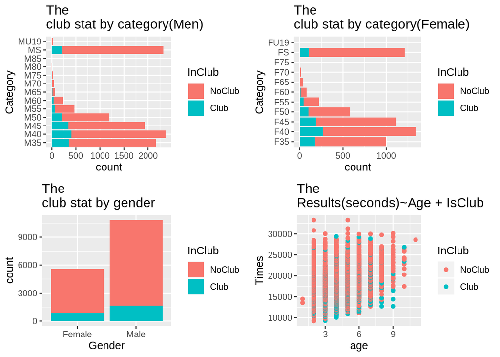

```r
getSeconds <- function(timeE)
{
 vHour <- c()
 for (i in 1:length(timeE)) {
 hour = 0
 strE = timeE[i]
 if (is.na(strE) == FALSE) {
 if ( nchar(strE) == 8 ) {
 eHour = as.integer(substr(strE, 1, 2))
 eMinute = as.integer(substr(strE, 4, 5))
 eSecond = as.integer(substr(strE, 7, 8))
 hour = as.integer(eHour* 3600 + eMinute * 60 + eSecond)
 }
 }
 hour
 vHour <- c(vHour, hour)
 }
 vHour
}
getAge <- function(category)
{
 vAge <- c()
 for (i in 1:length(category)) {
 age <- 0
 if (category[i] == 'MU19' | category[i] == 'FU19' )
 {
 age <- 1
 }
 else if (category[i] == 'MS' | category[i] == 'FS' )
 {
 age <- 2
 }
 else if (category[i] == 'M35' | category[i] == 'F35' )
 {
 age <- 3
 }
 else if (category[i] == 'M40' | category[i] == 'F40' )
 {
 age <- 4
 }
 else if (category[i] == 'M45' | category[i] == 'F45' )
 {
 age <- 5
 }
 else if (category[i] == 'M50' | category[i] == 'F50' )
 {
 age <- 6
 }
 else if (category[i] == 'M55' | category[i] == 'F55' )
 {
 age <- 7
 }
 else if (category[i] == 'M60' | category[i] == 'F60' )
 {
 age <- 8
 }
 else if (category[i] == 'M65' | category[i] == 'F65' )
 {
 age <- 9
 }
 else if (category[i] == 'M70' | category[i] == 'F70' )
 {
 age <- 10
 }
 else if (category[i] == 'M75' | category[i] == 'F75' )
 {
 age <- 11
 }
 else if (category[i] == 'M80' | category[i] == 'F80' )
 {
 age <- 12
 }
 vAge <- c(vAge, age)
 }
 vAge
}
mAll <- marathon
mAllP <- data.frame(mAll, InClub = ifelse(mAll$Club == "", 0, 1), count = 1, Times =
getSeconds(mAll$Gun.Time), age=getAge(mAll$Category))

mAllP$InClub <- factor(mAllP$InClub, labels=c("NoClub", "Club"))

p4<-ggplot(data = mAllP) + geom_bar(mapping = aes(x = Gender, fill=InClub)) + ggtitle('The
club stat by gender')

mAllPM <- subset(mAllP, mAllP$Gender == 'Male')
mAllPF <- subset(mAllP, mAllP$Gender == 'Female')

p1<-ggplot(data = mAllPM) + geom_bar(mapping = aes(x = Category, fill=InClub)) + ggtitle('The
club stat by category(Men)')+
coord_flip()

p2<-ggplot(data = mAllPF) + geom_bar(mapping = aes(x = Category, fill=InClub)) + ggtitle('The
club stat by category(Female)')+
coord_flip()

mAllPF <- subset(mAllPF, mAllPF$Times !=0)
p3<-ggplot(data = mAllPF ) +
geom_point(mapping = aes(x = age, y = Times, color=InClub)) + ggtitle('The
Results(seconds)~Age + IsClub')

grid.arrange( p1,p2 ,p4,p3, ncol=2,nrow=2)
```

In the first two graphs, we see that the age of 40 groups has the highest number of club participants for both males and females. In the third graph, we see that there are more males in clubs than females, however, there are also more males competing. In the fourth graph, we are looking at the results by age category and participation in a club or not.

```r
fit <-  glm(data=mAllPF,formula= Times~ age+InClub+age:InClub,family=poisson)

summary(fit)$coefficients
```

```
##                    Estimate   Std. Error      z value     Pr(>|z|)
## (Intercept)     9.749913400 0.0002867519 34001.217026 0.000000e+00
## age             0.023123562 0.0000658744   351.025035 0.000000e+00
## InClubClub     -0.106264411 0.0008433942  -125.996139 0.000000e+00
## age:InClubClub  0.001158442 0.0001867462     6.203295 5.529314e-10
```

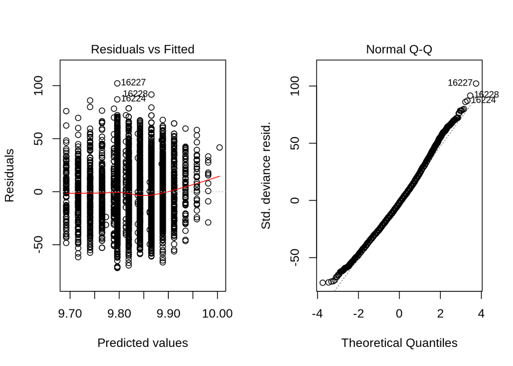

```r
par(mfrow=c(1,2))
suppressWarnings(plot(fit,which=c(1,2)))
```

## Conclusion

From the above, we can conclude that twice as many males compete and 95 percent of the top 100 finishers were male. The most popular categories are singles and 40’s aged groups for both genders. Single categorized participants seem to have a better gun time. It was interesting to see the same trend for average speed amongst the categories for the first half and second half of the marathon. We suspected that participation in a club would influence your result. Interestingly there were only 2551(15.5%) participants in a club but the results in the model were still significant.